# Analysis of binary outcome and continuos explanatory variables measured at timepoints

### Most common value removed

Plot the distrubution of the measurements of cytokines (C1-C12 and C13-C17)

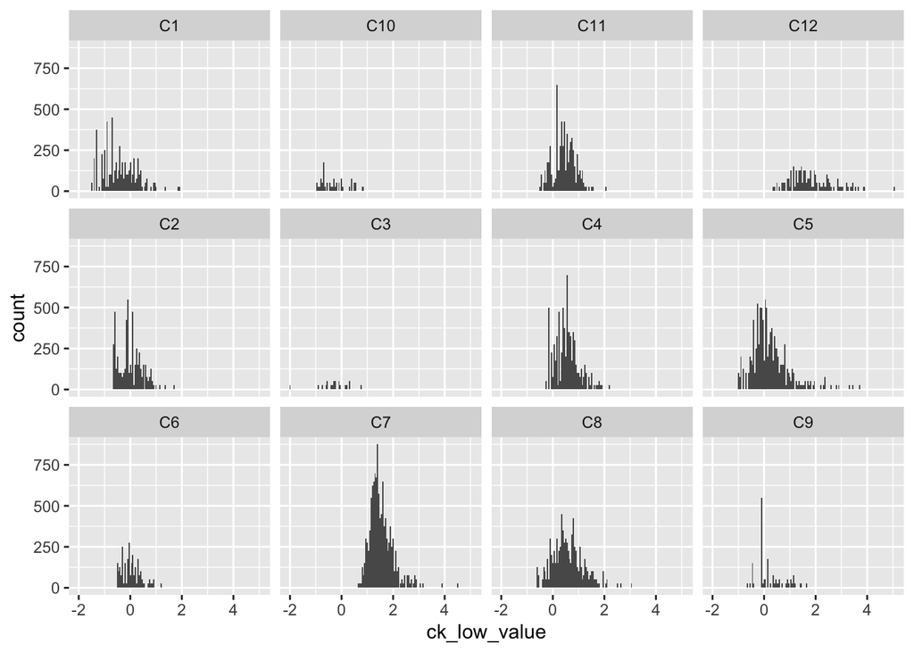

```r
#Histograms of Cytokines, low count values
ggplot(data = d_test_long) +
  geom_histogram(mapping = aes(x = ck_low_value),binwidth = 0.05) +
  facet_wrap( ~ ck_low)
```

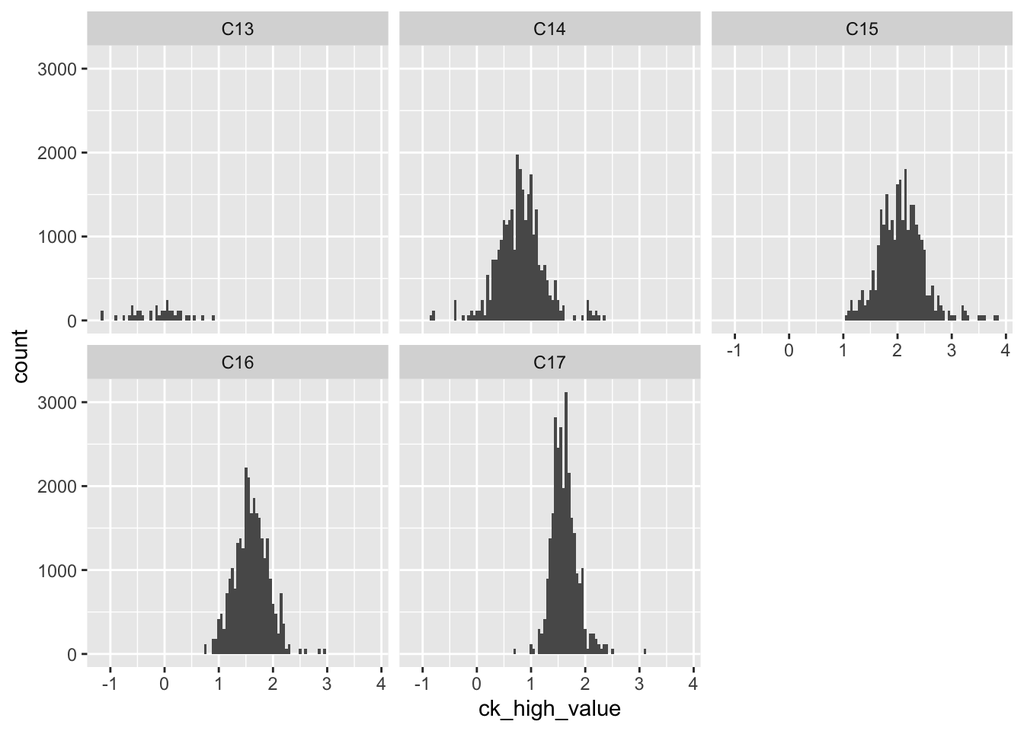

```r
#Histograms of cytokine, high count values
ggplot(data = d_test_long) +
  geom_histogram(mapping = aes(x = ck_high_value),binwidth = 0.05) +
  facet_wrap( ~ ck_high)
```

Plot the distrubution of the measurements of growth factors (G1-G5). The filtering strategy has not been working for this data set. Would have to look further into this.

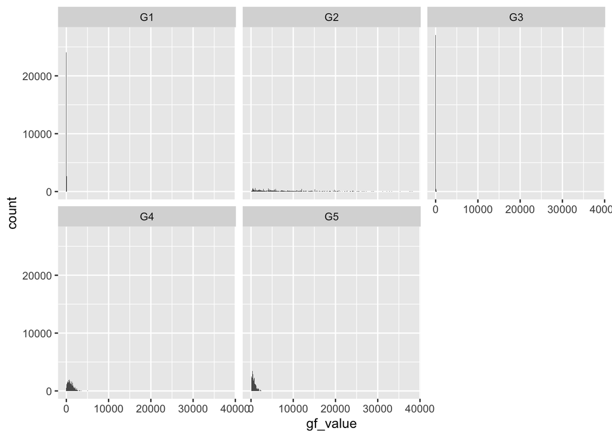

```r
#Histograms of growth factors, low count values
ggplot(data = d_test_long) +
  geom_histogram(mapping = aes(x = gf_value),binwidth = 100) +
  facet_wrap( ~ gf)
```

## Plots of covariation of variables.

These plots indicate correlation betwwen varialbes. The dot plot cloud is streched out from lower left to upper right. The cloud is not symmetric.

```r
d_long2 <- gather(d, "ck_low", "ck_low_val",c(C2:C13))
d_long2 <- gather(d_long2, "ck_high", "ck_high_val",c(C14:C17))
d_long2 <- gather(d_long2, "gf", "gf_val",c(G3:G5))
```

Plot covariation ck1

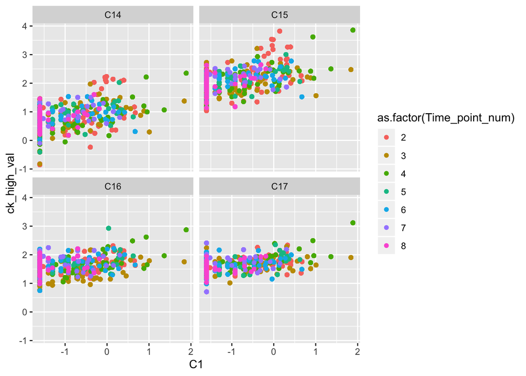

```r
ggplot(data = d_long2) +
  geom_point(mapping = aes(x = C1, y = ck_high_val, color = as.factor(Time_point_num))) +#
  facet_wrap( ~  ck_high)
```

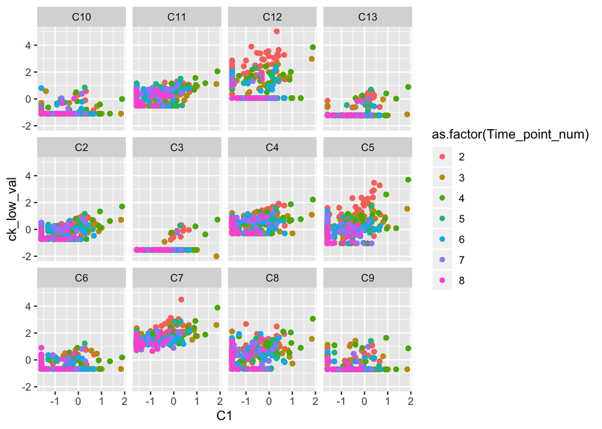

```r
ggplot(data = d_long2) +
  geom_point(mapping = aes(x = C1, y = ck_low_val, color = as.factor(Time_point_num))) +
  facet_wrap( ~  ck_low)
```

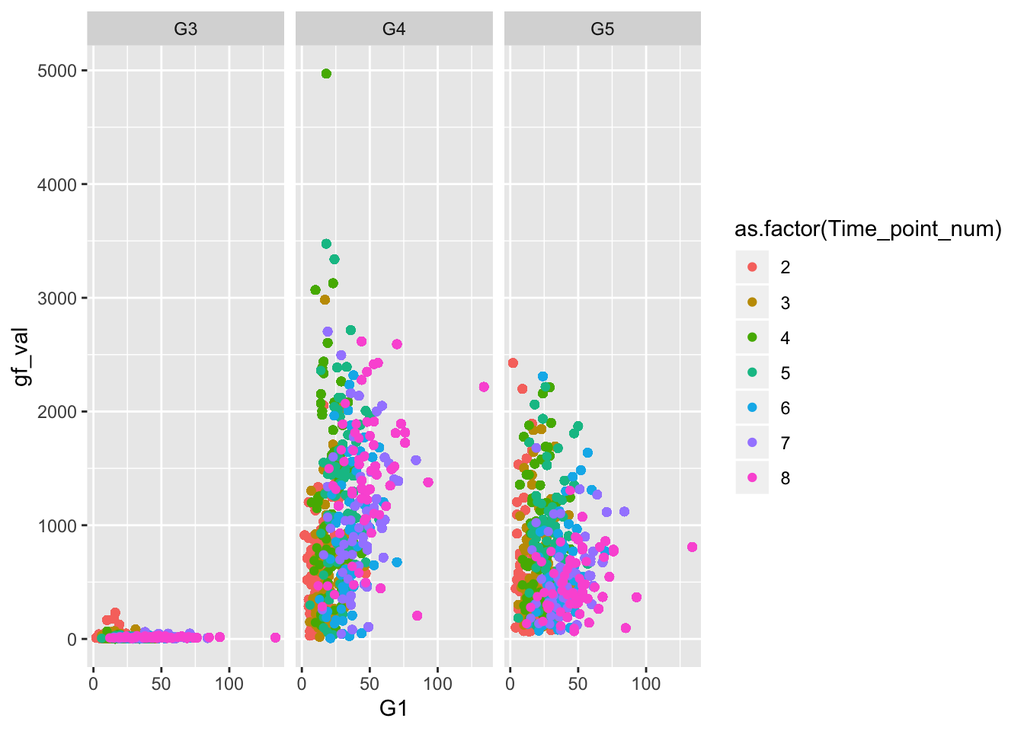

```r
ggplot(data = d_long2) +
  geom_point(mapping = aes(x = G1, y = gf_val, color = as.factor(Time_point_num))) +
  facet_wrap( ~  gf)
```

# Data analysis

The data to be analysed is made up by continuos variables measured over time and a binary one, and finally binary outcome variable. This limits the number of research question that can be asked. I suggest that the most relevant question involving all variables is weather any of the variables effect the time to outcome? What is needed is a survival analysis. Since the indepent variables are continuos this requires a Cox proportional hazards regression.

## Cox proportional hazards regression

For this analyis the coxph function of the “survival” package will be used. It is called as coxph(formula, data, method) * formula: is linear model with a survival object as the response variable. Survival object is created using the function Surv() as follow: Surv(time, event). * data: a data frame containing the variables * method: is used to specify how to handle ties. The default is ‘efron’. Other options are ‘breslow’ and ‘exact’. The default ‘efron’ is generally preferred to the once-popular “breslow” method. The “exact” method is much more computationally intensive.

## Univariate Cox regression with single variable

An initial look at the effect of the sex variable

```r
res.cox <- coxph(Surv(Time_point_num, outcome) ~ sex, data = d)
res.cox
```

```
## Call:
## coxph(formula = Surv(Time_point_num, outcome) ~ sex, data = d)
##
##                 coef        exp(coef)         se(coef)       z       p
## sex 0.00357470826085 1.00358110515049 0.12886532365286 0.02774 0.97787
##
## Likelihood ratio test=0  on 1 df, p=0.977870495233
## n= 464, number of events= 242
```

```r
summary(res.cox)
```

```
## Call:
## coxph(formula = Surv(Time_point_num, outcome) ~ sex, data = d)
##
##   n= 464, number of events= 242
##
##                 coef        exp(coef)         se(coef)       z Pr(>|z|)
## sex 0.00357470826085 1.00358110515049 0.12886532365286 0.02774  0.97787
##
##         exp(coef)     exp(-coef)      lower .95     upper .95
## sex 1.00358110515 0.996431673402 0.779582557732 1.29194146871
##
## Concordance= 0.502  (se = 0.02 )
## Likelihood ratio test= 0  on 1 df,   p=0.9778705
## Wald test            = 0  on 1 df,   p=0.97786962
## Score (logrank) test = 0  on 1 df,   p=0.97786961
```

## Applying the univariate coxph function for each variable

Univariate regression is performed at each variable one by one to single out signficant ones

```r
covariates <- names(d)[3:25]
univ_formulas <- sapply(covariates,
                        function(x) as.formula(paste('Surv(Time_point_num, outcome)~', x)))

univ_models <- lapply( univ_formulas, function(x){coxph(x, data = d)})
# Extract data
univ_results <- lapply(univ_models,
                       function(x){
                         x <- summary(x)
                         p.value<-signif(x$wald["pvalue"], digits=2)
                         wald.test<-signif(x$wald["test"], digits=2)
                         beta<-signif(x$coef[1], digits=2);#coeficient beta
                         HR <-signif(x$coef[2], digits=2);#exp(beta)
                         HR.confint.lower <- signif(x$conf.int[,"lower .95"], 2)
                         HR.confint.upper <- signif(x$conf.int[,"upper .95"],2)
                         HR <- paste0(HR, " (",
                                      HR.confint.lower, "-", HR.confint.upper, ")")
                         res<-c(beta, HR, wald.test, p.value)
                         names(res)<-c("beta", "HR (95% CI for HR)", "wald.test",
                                       "p.value")
                         return(res)
                         #return(exp(cbind(coef(x),confint(x))))
                       })
res <- t(as.data.frame(univ_results, check.names = FALSE))
```

## Multivariate Cox regression

```r
res_filt <- res[as.numeric(res[,4]) <= 0.001, ]
rownames(res_filt)
```

```
##  [1] "C1"  "C3"  "C4"  "C5"  "C7"  "C8"  "C12" "C13" "G1"  "G2"  "G4"
```

```r
ind_var <- paste(rownames(res_filt),sep="",collapse=" + ") # havent figure out how to use tis as input
res.cox <- coxph(Surv(time, status) ~ age + sex + ph.ecog, data =  lung)
res.cox <- coxph(Surv(Time_point_num, outcome) ~ C1 + C2 + C3 + C4 + C5 + C7 + C8 + C9 + C12 + C13 + G1 + G2 + G4 , data = d)
res.cox
```

```
## Call:
## coxph(formula = Surv(Time_point_num, outcome) ~ C1 + C2 + C3 +
##     C4 + C5 + C7 + C8 + C9 + C12 + C13 + G1 + G2 + G4, data = d)
##
##                   coef          exp(coef)           se(coef)        z
## C1  -2.69562828099e-02  9.73403795073e-01  1.26819703700e-01 -0.21256
## C2  -3.44976121437e-01  7.08237264954e-01  2.21341418281e-01 -1.55857
## C3  -8.43977645264e-01  4.29996742775e-01  4.03797603556e-01 -2.09010
## C4  -7.58004829738e-02  9.27001140621e-01  1.76832010531e-01 -0.42866
## C5   6.34015055366e-01  1.88516444414e+00  1.51058836664e-01  4.19714
## C7   1.52324480533e-01  1.16453804506e+00  2.26251724527e-01  0.67325
## C8  -8.62440071744e-02  9.17370358959e-01  1.14662243536e-01 -0.75216
## C9   5.46376564294e-01  1.72698405145e+00  2.26169948164e-01  2.41578
## C12  1.08989046474e-01  1.11515013545e+00  1.23689654610e-01  0.88115
## C13  2.96683703569e-01  1.34538969018e+00  3.94550536536e-01  0.75195
## G1  -3.54401499126e-02  9.65180498639e-01  6.22535617857e-03 -5.69287
## G2  -6.98465376857e-05  9.99930155902e-01  1.54583668968e-05 -4.51836
## G4   3.30177167577e-04  1.00033023168e+00  1.42402529754e-04  2.31862
##              p
## C1    0.831673
## C2    0.119098
## C3    0.036609
## C4    0.668172
## C5  2.7031e-05
## C7    0.500787
## C8    0.451957
## C9    0.015702
## C12   0.378237
## C13   0.452079
## G1  1.2492e-08
## G2  6.2319e-06
## G4    0.020416
##
## Likelihood ratio test=201.79  on 13 df, p=< 2.220446049e-16
## n= 464, number of events= 242
```

```r
summary(res.cox)
```

```
## Call:
## coxph(formula = Surv(Time_point_num, outcome) ~ C1 + C2 + C3 +
##     C4 + C5 + C7 + C8 + C9 + C12 + C13 + G1 + G2 + G4, data = d)
##
##   n= 464, number of events= 242
##
##                   coef          exp(coef)           se(coef)        z
## C1  -2.69562828099e-02  9.73403795073e-01  1.26819703700e-01 -0.21256
## C2  -3.44976121437e-01  7.08237264954e-01  2.21341418281e-01 -1.55857
## C3  -8.43977645264e-01  4.29996742775e-01  4.03797603556e-01 -2.09010
## C4  -7.58004829738e-02  9.27001140621e-01  1.76832010531e-01 -0.42866
## C5   6.34015055366e-01  1.88516444414e+00  1.51058836664e-01  4.19714
## C7   1.52324480533e-01  1.16453804506e+00  2.26251724527e-01  0.67325
## C8  -8.62440071744e-02  9.17370358959e-01  1.14662243536e-01 -0.75216
## C9   5.46376564294e-01  1.72698405145e+00  2.26169948164e-01  2.41578
## C12  1.08989046474e-01  1.11515013545e+00  1.23689654610e-01  0.88115
## C13  2.96683703569e-01  1.34538969018e+00  3.94550536536e-01  0.75195
## G1  -3.54401499126e-02  9.65180498639e-01  6.22535617857e-03 -5.69287
## G2  -6.98465376857e-05  9.99930155902e-01  1.54583668968e-05 -4.51836
## G4   3.30177167577e-04  1.00033023168e+00  1.42402529754e-04  2.31862
##       Pr(>|z|)
## C1    0.831673
## C2    0.119098
## C3    0.036609 *
## C4    0.668172
## C5  2.7031e-05 ***
## C7    0.500787
## C8    0.451957
## C9    0.015702 *
## C12   0.378237
## C13   0.452079
## G1  1.2492e-08 ***
## G2  6.2319e-06 ***
## G4    0.020416 *
## ---
## Signif. codes:  0 '***' 0.001 '**' 0.01 '*' 0.05 '.' 0.1 ' ' 1
##
##          exp(coef)     exp(-coef)      lower .95      upper .95
## C1  0.973403795073 1.027322890112 0.759178512739 1.248079249298
## C2  0.708237264954 1.411956203779 0.458957654323 1.092911336690
## C3  0.429996742775 2.325599011624 0.194873157724 0.948807937209
## C4  0.927001140621 1.078747324227 0.655481725471 1.310991720013
## C5  1.885164444140 0.530457702567 1.402063634502 2.534724454723
## C7  1.164538045058 0.858709600982 0.747425420217 1.814426993926
## C8  0.917370358959 1.090072281314 0.732730087422 1.148538035960
## C9  1.726984051453 0.579044142972 1.108592964298 2.690323689599
## C12 1.115150135448 0.896740239912 0.875081528250 1.421078818882
## C13 1.345389690184 0.743279071704 0.620877711635 2.915346105257
## G1  0.965180498639 1.036075637055 0.953475428744 0.977029262495
## G2  0.999930155902 1.000069848977 0.999899860634 0.999960452087
## G4  1.000330231682 0.999669877335 1.000051074642 1.000609466647
##
## Concordance= 0.835  (se = 0.012 )
## Likelihood ratio test= 201.79  on 13 df,   p=< 2.22045e-16
## Wald test            = 179.93  on 13 df,   p=< 2.22045e-16
## Score (logrank) test = 196.36  on 13 df,   p=< 2.22045e-16
```